# Categorical variables

Some variables, consist of named categories, e.g. the name of your favourite brand. A category-variable, or a categorical variable refers to any variable that puts individuals into categories. These variables are also called nominal variables. The word *nominal* comes from Latin (*nominalis*=of a name), because we are giving names to the values of our variable.

There are numerous data types in R. The most frequent used ones are numeric, character (string) or factor, and logical (TRUE or FALSE). To check the type of data contained in a variable we can use the `class()` function.

```r
load("EVS_UK.RData")
```

To find the length of a character variable we use the `nchar()` function.

```r
EVS_UK$education<-EVS_UK$v243_r_weight
table(EVS_UK$education)
```

```
##
##   1   2   3
## 590 313 885
```

As you know, education is a classic example of a categorical variable. How can we assign labels to the values of the variable? This is easy.

Note that as the same time we will learn how to covert a variable to factor but also we will give a name to the values.

Let’s do it!

```r
EVS_UK$education <- factor(EVS_UK$education,
                         levels = c(1, 2, 3),
                         labels = c("Low", "Medium", "Upper"))
table(EVS_UK$education)
```

```
##
##    Low Medium  Upper
##    590    313    885
```

Let’s examine our new factor variable with a frequency table

```r
table(EVS_UK$education)
```

```
##
##    Low Medium  Upper
##    590    313    885
```

The most common graphical representation of categorical variables is bar graphs and pie charts.

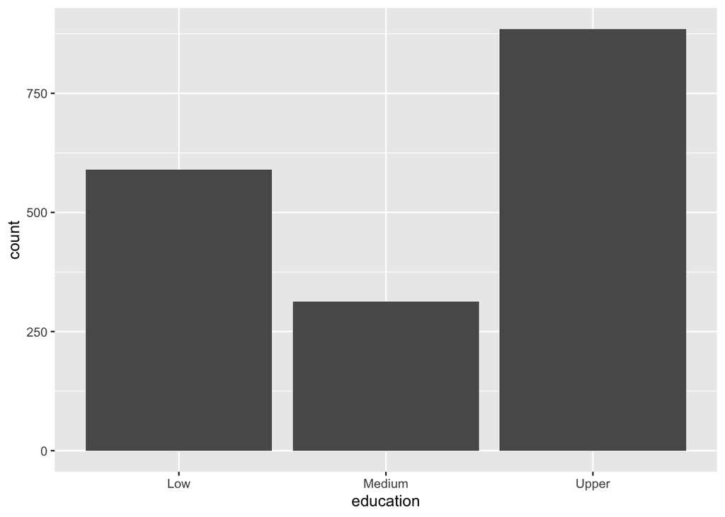

```r
library(ggplot2)
ggplot(data.frame(EVS_UK), aes(x=education)) +
  geom_bar()
```